# Trabajo_CausalTree_Group2

Diego Alonso Gómez and partner

11/11/2021

## R Markdown

When a sampling unit is drawn from a finite population and returned to that population, after its characteristics have been registered, before the next drive is removed, it is said that sampling is “with replacement”. Otherwise, the sampling is “without replacement”.

Sampling is called with replacement When a selected unit randomly from the population is returned to the population and then a second item at random. Whenever a unit is selected, the population contains all the same units, so one unit can be selected more than once.

```r
library(usethis)
library(devtools)
library(causalTree)
library(causalTree)
library(grf)
library(rpart)
library(glmnet)
library(splines)
library(MASS)
library(lmtest)
```

```r
library(sandwich)
library(ggplot2)
```

```r
getwd()
```

```
## [1] "C:/Users/Diego/Documents"
```

```r
setwd("C:\\Users\\Diego\\Desktop\\Estadistica Aplicada\\Para trabajo grupal 11 de Noviembre")
# Read in Penn
data <- as.data.frame(read.table("..//data//penn_jae.dat", header=T ))

n <- dim(data)[1]
p_1 <- dim(data)[2]
data<- subset(data, tg== 4| tg==0)
attach(data)
T4<- (tg==4)
T4<-as.numeric(T4)
data=cbind(data,T4)
```

```r
treatment <- "T4"
# Outcome: 1 for 'yes', 0 for 'no'
outcome <- "log(inuidur1)"

# Additional covariates
covariates <- c("female", "black", "othrace", "factor(dep)", "q2", "q3","q4","q5","q6","agelt35","agegt54","durable","lusd","husd")


m <- lm(log(inuidur1)~T4*female+black+othrace+factor(dep)+q2+q3+q4+q5+q6+agelt35+agegt54+durable+lusd+husd,data=data)
coeftest(m, vcov = vcovHC(m, type="HC2"))
```

```
##
## t test of coefficients:
##
##                Estimate Std. Error t value  Pr(>|t|)
## (Intercept)   2.1866134  0.1546279 14.1411 < 2.2e-16 ***
## T4           -0.1067286  0.0456101 -2.3400  0.019321 *
## female        0.0965599  0.0431095  2.2399  0.025142 *
## black        -0.2949657  0.0594562 -4.9611 7.240e-07 ***
## othrace      -0.4681574  0.2438624 -1.9198  0.054944 .
## factor(dep)1  0.0285410  0.0542094  0.5265  0.598567
## factor(dep)2  0.0955944  0.0463860  2.0608  0.039369 *
## q2            0.0792115  0.1518598  0.5216  0.601965
## q3           -0.0333002  0.1516822 -0.2195  0.826239
## q4           -0.0495716  0.1520543 -0.3260  0.744428
## q5           -0.1380873  0.1518515 -0.9094  0.363204
## q6            0.0059989  0.1633621  0.0367  0.970708
## agelt35      -0.1645460  0.0370277 -4.4439 9.024e-06 ***
## agegt54       0.2285792  0.0578868  3.9487 7.963e-05 ***
## durable       0.1265560  0.0481703  2.6273  0.008633 **
## lusd         -0.1753120  0.0404572 -4.3333 1.497e-05 ***
## husd         -0.1049685  0.0442228 -2.3736  0.017651 *
## T4:female     0.0869164  0.0723464  1.2014  0.229655
## ---
## Signif. codes:  0 '***' 0.001 '**' 0.01 '*' 0.05 '.' 0.1 ' ' 1
```

```r
indices <- split(seq(nrow(data)), sort(seq(nrow(data)) %% 3))
names(indices) <- c('split', 'est', 'test')


# Fitting the forest
ct.unpruned <- honest.causalTree(
  formula=lm(log(inuidur1)~T4+ (female+black+othrace+factor(dep)+q2+q3+q4+q5+q6+agelt35+agegt54+durable+lusd+husd)), # Define the model
  data=data[indices$split,],
  treatment=data[indices$split, treatment],
  est_data=data[indices$est,],
  est_treatment=data[indices$est, treatment],
  minsize=1,                 # Min. number of treatment and control cases in each leaf
  HonestSampleSize=length(indices$est), #  Num obs used in estimation after splitting

  # We recommend not changing the parameters below
  split.Rule="CT",            # Define the splitting option
  cv.option="TOT",            # Cross validation options
  cp=0,                       # Complexity parameter
  split.Honest=TRUE,          # Use honesty when splitting
  cv.Honest=TRUE              # Use honesty when performing cross-validation
)
```

```
## [1] 2
## [1] "CT"
```

```r
# Table of cross-validated values by tuning parameter.
ct.cptable <- as.data.frame(ct.unpruned$cptable)


# Obtain optimal complexity parameter to prune tree.
cp.selected <- which.min(ct.cptable$xerror)

cp.optimal <- ct.cptable[cp.selected, "CP"]

# Prune the tree at optimal complexity parameter.
ct.pruned <- prune(tree=ct.unpruned, cp=cp.optimal)

# Predict point estimates (on estimation sample)
tau.hat.est <- predict(ct.pruned, newdata=data[indices$est,])

# Create a factor column 'leaf' indicating leaf assignment in the estimation set
num.leaves <- length(unique(tau.hat.est))
leaf <- factor(tau.hat.est, levels=sort(unique(tau.hat.est)), labels = seq(num.leaves))
```

## 1° Question: • Explain why we need to partitionate the data in three sets.

We believe that it is necessary and it is necessary to partition the data because it is necessary to write the average effects of W_i and G_i on Y_i, all this to obtain the estimator $ B_ {wg}$ that allow us to test the hyphotesis that the treatment effect is the same regardless of membership to some group $ G_i$, ie $ B_ {wg} = 0$.

## 2° Question: • Why do we need to use the honest.causalTree function?

The honest.causal Tree function is used to implement the algorithm developed by Susan Athey. This allows creating the tree in such a way that for each step of the algorithm the 3 parts of our data are used: “split”, “est” and “test”, in such a way that they do not repeat observations among themselves. This allows us to avoid the problem of “overfitting” and to evaluate our results in a better way.

## 3° Question: Explain in detail the creation of the tree and how do you choose the optimal pruned tree

The creation of the tree consists of these setps. 1st in the split, the whole optimization process is carried out to be able to find which is the ideal tree that minimizes the mean squared error for all variables. Then in the partition “est” with that tree that has been found, the heterogeneous effects with that tree will be searched, but using the data of the partition “est”. Finally, with what was found in this second stage, it will be tested with the “test” partition, this to see if the outcome found looks like the true outcome or not.

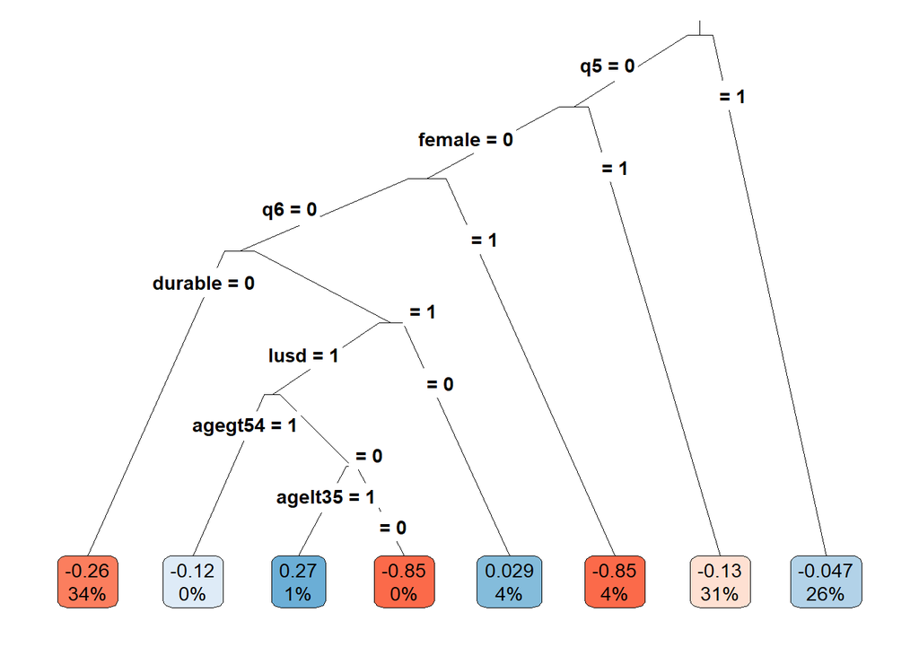

```r
rpart.plot(
  x=ct.pruned,        # Pruned tree
  type=3,             # Draw separate split labels for the left and right directions
  fallen=TRUE,        # Position the leaf nodes at the bottom of the graph
  leaf.round=1,       # Rounding of the corners of the leaf node boxes
  extra=100,          # Display the percentage of observations in the node
  branch=.1,          # Shape of the branch lines
  box.palette="RdBu") # Palette for coloring the node
```